# Projet : programmation statistique avec Python

- BUT 2 - VCOD/EMS
- Année académique 2024/2025
- Adresse :
  - Centre Borelli – Université de Paris Cité
  - IUT Paris Rives de Seine
- Mail : amine.meddour@u-paris.fr
- Remise du projet : **Vous devez envoyer votre notebook (ou script python) + préparer un support de présentation sur powerpoint pour présenter votre travail au plus tard le 8 janvier 2025 avant minuit. (Important : 3 étudiants maximum par groupe)**.

## Objectif :

- Ce projet est un travail pratique sur données réelles. Il s'agit de mettre en place une analyse exploratoire du jeu de données de crédits décrivant les détails financiers et bancaires des clients d’une banque en utilisant un certain nombre de packages Python (pandas, numpy,scipy, matplotlib et scikit-learn,..).
- Présentation du projet
  - Le notebook doit présenter de façon claire et concise:
  - l'objet de l'analyse
  - la description des données (individus/variables utilisées, variables supplémentaires etc.)
  - l'analyse proprement dite
  - les commentaires sur les résultats obtenus.
  - les commentaires sur le code utilisé.

**Vous devez envoyer votre notebook (ou script python) + préparer un support de présentation sur powerpoint pour présenter votre travail au plus tard le 8 janvier 2025 avant minuit. (Important : 3 étudiants maximum par groupe)**.

### Présentation des données

- **Données** : L'ensemble de données de crédits décrit les détails financiers et bancaires des clients et la tâche consiste à déterminer si le client est bon ou mauvais. L'hypothèse est que la tâche consiste à prédire si un client remboursera un prêt ou un crédit. L'ensemble de données comprend 1000 exemples et 20 variables, dont 7 numériques (entiers) et 13 catégorielles. La dernière colonne de la table fait référence à la variable cible : 1: bon client et 2: mauvais client.
- **Noms des variables** : (Statut du compte courant existant, Durée en mois, Historique de crédit, Objectif, Montant du crédit, Compte d'épargne, Emploi actuel depuis, Taux de versement en, pourcentage du revenu disponible, Statut personnel et sexe, Autres débiteurs,Résidence actuelle depuis, Propriété, Age en années, Autres plans de versement, Logement, Nombre de crédits existants dans cette banque, Travail, Nombre de personnes à charge, Téléphone, Travailleur étranger).
- Lors du chargement de la table, vous pouvez renommer les variables en utilisant la liste suivante : columns = ['statut_compte', 'duree_mois', 'historique', 'objectif', 'montant', 'epargne', 'emploi', 'taux_versement', 'statut_sexe', 'autre_debiteurs', 'residence', 'propriete', 'age', 'plan_versement', 'logement', 'n_credit', 'travail', 'n_p_charge', 'tel', 'trav_etranger']
- y étant la variable cible (des labels) qui prend deux valeurs (1 et 2), 1:= désigne un bon client et 2 désigne un mauvais client.
- **Source et description des données Crédits** :

https://archive.ics.uci.edu/dataset/144/statlog+german+credit+data

### Chargement et description des données

```python
#In a Jupyter notebook, install with the command
!pip3 install -U ucimlrepo
# Restart the kernel and import the module ucimlrepo.
```

```python
import ucimlrepo
```

```python
# Installer le package ucimlrepo

#pip install ucimlrepo


# Importer les données

from ucimlrepo import fetch_ucirepo

# Récupérer l'ensemble de données
statlog_german_credit_data = fetch_ucirepo(id=144)

# Les données (sous forme de dataframes pandas)
X = statlog_german_credit_data.data.features
y = statlog_german_credit_data.data.targets
```

```python
# metadata
#print(statlog_german_credit_data.metadata)

# variable information
print(statlog_german_credit_data.variables)
print(statlog_german_credit_data.variables[['name','description']])
```

```
           name     role         type     demographic  \
0    Attribute1  Feature  Categorical            None
1    Attribute2  Feature      Integer            None
2    Attribute3  Feature  Categorical            None
3    Attribute4  Feature  Categorical            None
4    Attribute5  Feature      Integer            None
5    Attribute6  Feature  Categorical            None
6    Attribute7  Feature  Categorical           Other
7    Attribute8  Feature      Integer            None
8    Attribute9  Feature  Categorical  Marital Status
9   Attribute10  Feature  Categorical            None
10  Attribute11  Feature      Integer            None
11  Attribute12  Feature  Categorical            None
12  Attribute13  Feature      Integer             Age
13  Attribute14  Feature  Categorical            None
```

[output cut: 52 more lines]

## Partie 1 : Manipulation, analyse et visualisation des données statlog_german_credit_data

- Commencer par une étude exploratoire préliminaire
  - Chargement des données
  - Description des données
  - Visualisation: Représentations Graphiques , univariée et bivariée, croisement des variables
  - Scinder le dataset en deux sous ensemble data-qualitative et data-quantitative

```
--- Description statistique des variables numériques ---

        duree_mois       montant  taux_versement    residence          age  \
count  1000.000000   1000.000000     1000.000000  1000.000000  1000.000000
mean     20.903000   3271.258000        2.973000     2.845000    35.546000
std      12.058814   2822.736876        1.118715     1.103718    11.375469
min       4.000000    250.000000        1.000000     1.000000    19.000000
25%      12.000000   1365.500000        2.000000     2.000000    27.000000
50%      18.000000   2319.500000        3.000000     3.000000    33.000000
75%      24.000000   3972.250000        4.000000     4.000000    42.000000
max      72.000000  18424.000000        4.000000     4.000000    75.000000

          n_credit   n_p_charge       target
count  1000.000000  1000.000000  1000.000000
mean      1.407000     1.155000     1.300000
std       0.577654     0.362086     0.458487
min       1.000000     1.000000     1.000000
25%       1.000000     1.000000     1.000000
50%       1.000000     1.000000     1.000000
75%       2.000000     1.000000     2.000000
max       4.000000     2.000000     2.000000

--- Aperçu des variables qualitatives ---

statut_compte: ['A11' 'A12' 'A14' 'A13']
historique: ['A34' 'A32' 'A33' 'A30' 'A31']
objectif: ['A43' 'A46' 'A42' 'A40' 'A41' 'A49' 'A44' 'A45' 'A410' 'A48']
epargne: ['A65' 'A61' 'A63' 'A64' 'A62']
emploi: ['A75' 'A73' 'A74' 'A71' 'A72']
statut_sexe: ['A93' 'A92' 'A91' 'A94']
autre_debiteurs: ['A101' 'A103' 'A102']
propriete: ['A121' 'A122' 'A124' 'A123']
plan_versement: ['A143' 'A141' 'A142']
logement: ['A152' 'A153' 'A151']
travail: ['A173' 'A172' 'A174' 'A171']
tel: ['A192' 'A191']
trav_etranger: ['A201' 'A202']

--- Distribution de la variable cible ---

target
1    700
2    300
Name: count, dtype: int64
```

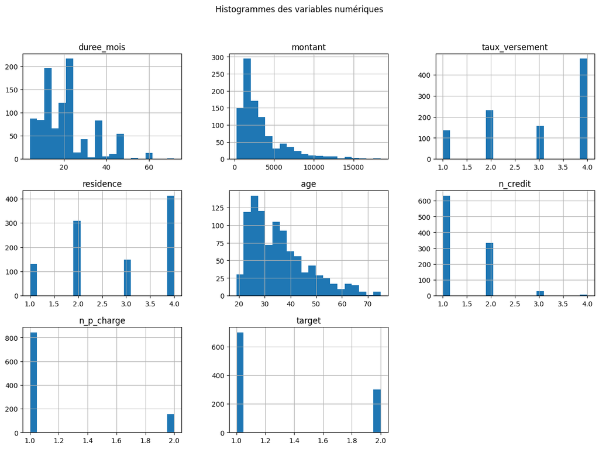

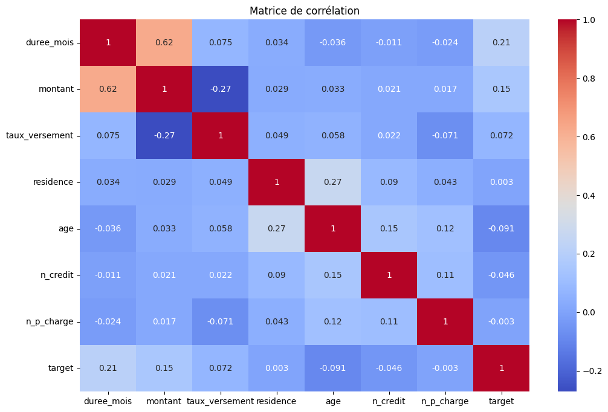

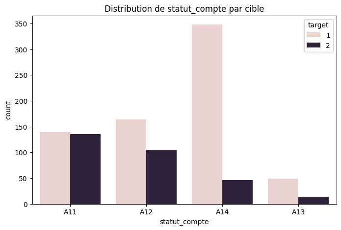

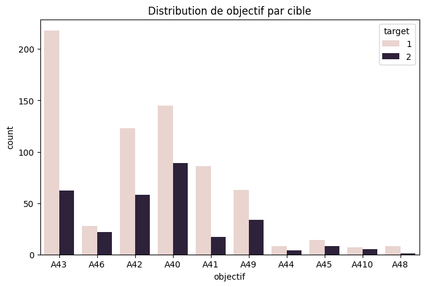

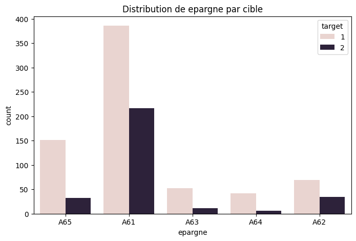

```
--- Dimensions des données qualitatives : (1000, 13)
--- Dimensions des données quantitatives : (1000, 8)
```

```python
# Importer les bibliothèques nécessaires
import pandas as pd
import numpy as np
import matplotlib.pyplot as plt
import seaborn as sns

# Charger les données
columns = ['statut_compte', 'duree_mois', 'historique', 'objectif', 'montant', 'epargne', 'emploi',
           'taux_versement', 'statut_sexe', 'autre_debiteurs', 'residence', 'propriete', 'age',
           'plan_versement', 'logement', 'n_credit', 'travail', 'n_p_charge', 'tel', 'trav_etranger']

# Assurez-vous que les données sont correctement chargées et les colonnes nommées
def load_data():
    from ucimlrepo import fetch_ucirepo
    statlog_german_credit_data = fetch_ucirepo(id=144)
    X = statlog_german_credit_data.data.features
    y = statlog_german_credit_data.data.targets
    X.columns = columns
    return X, y

# Charger les données
X, y = load_data()

# Ajouter la colonne cible aux données
data = X.copy()
data['target'] = y

# Analyse univariée
def univariate_analysis(df):
    print("\n--- Description statistique des variables numériques ---\n")
    print(df.describe())

    print("\n--- Aperçu des variables qualitatives ---\n")
    for col in df.select_dtypes(include=['object']).columns:
        print(f"{col}: {df[col].unique()}")

    print("\n--- Distribution de la variable cible ---\n")
    print(df['target'].value_counts())

univariate_analysis(data)

# Visualisation des données
def visualize_data(df):
    # Distribution des variables numériques
    df.select_dtypes(include=[np.number]).hist(figsize=(15, 10), bins=20)
    plt.suptitle('Histogrammes des variables numériques')
    plt.show()

    # Corrélations
    plt.figure(figsize=(12, 8))
    sns.heatmap(df.select_dtypes(include=[np.number]).corr(), annot=True, cmap='coolwarm')
    plt.title('Matrice de corrélation')
    plt.show()

    # Relation entre certaines variables qualitatives et la cible
    for col in ['statut_compte', 'objectif', 'epargne']:
        if col in df.columns:
            plt.figure(figsize=(8, 5))
            sns.countplot(data=df, x=col, hue='target')
            plt.title(f"Distribution de {col} par cible")
            plt.show()

visualize_data(data)

# Scinder les données en qualitatives et quantitatives
data_qualitative = data.select_dtypes(include=['object'])
data_quantitative = data.select_dtypes(include=[np.number])

print("\n--- Dimensions des données qualitatives :", data_qualitative.shape)
print("--- Dimensions des données quantitatives :", data_quantitative.shape)
```

## Partie 2: - Etude exploratoire multidimensionnelles: ACP et classification de type CAH et k-means

L'objectif de cette partie est de réaliser une étude exploratoire multidimensionnelle qui comporte les étapes suivantes :

- Réalisation d'une ACP (Analyse en Composantes Principales) sur la base des données quantitatives.
- Clustering des données à l'aide :
  - k-means ou CAH (Classification Ascendante Hiérarchique),
  - Projection des clusters sur le premier plan factoriel de l'ACP.
  - Interprétation concise des résultats obtenus.

```python
!pip install scikit-learn
!pip install matplotlib seaborn
```

```
Données brutes :
  Attribute1  Attribute2 Attribute3 Attribute4  Attribute5 Attribute6  \
0        A11           6        A34        A43        1169        A65
1        A12          48        A32        A43        5951        A61
2        A14          12        A34        A46        2096        A61
3        A11          42        A32        A42        7882        A61
4        A11          24        A33        A40        4870        A61

  Attribute7  Attribute8 Attribute9 Attribute10  Attribute11 Attribute12  \
0        A75           4        A93        A101            4        A121
1        A73           2        A92        A101            2        A121
2        A74           2        A93        A101            3        A121
3        A74           2        A93        A103            4        A122
4        A73           3        A93        A101            4        A124

   Attribute13 Attribute14 Attribute15  Attribute16 Attribute17  Attribute18  \
0           67        A143        A152            2        A173            1
1           22        A143        A152            1        A173            1
2           49        A143        A152            1        A172            2
3           45        A143        A153            1        A173            2
4           53        A143        A153            2        A173            2

  Attribute19 Attribute20
0        A192        A201
1        A191        A201
2        A191        A201
3        A191        A201
4        A191        A201
Colonnes quantitatives sélectionnées :
Index(['Attribute2', 'Attribute5', 'Attribute8', 'Attribute11', 'Attribute13',
       'Attribute16', 'Attribute18'],
      dtype='object')
```

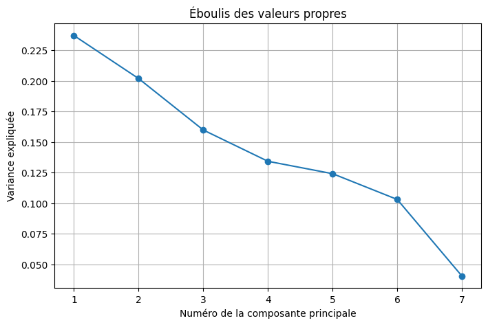

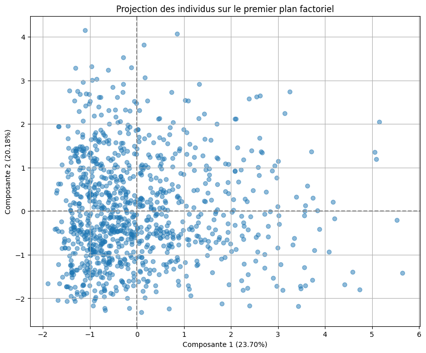

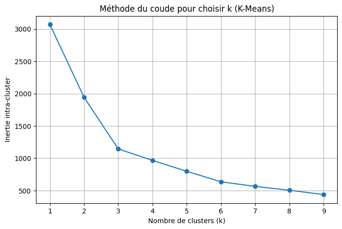

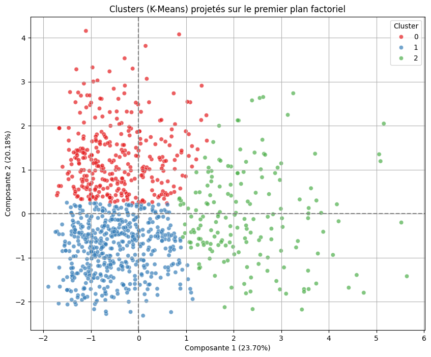

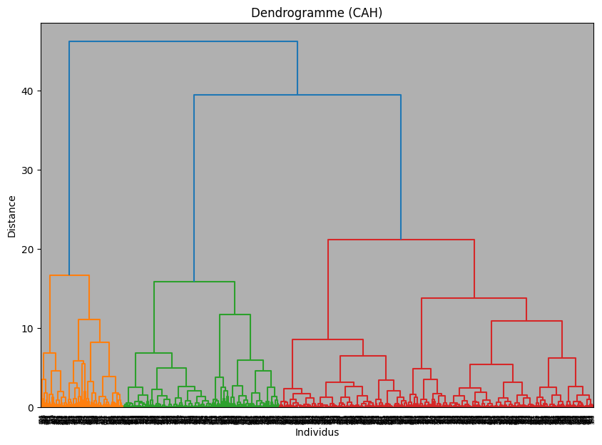

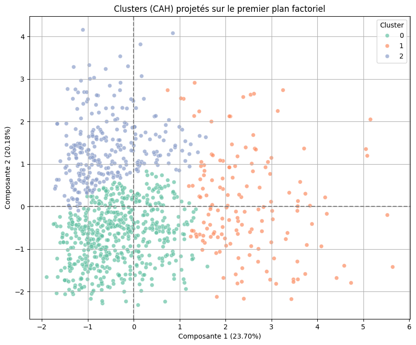

```python
# Installer le package ucimlrepo si nécessaire
#pip install ucimlrepo

# Importer les données
from ucimlrepo import fetch_ucirepo
from sklearn.decomposition import PCA
from sklearn.preprocessing import StandardScaler
from sklearn.cluster import KMeans, AgglomerativeClustering
from scipy.cluster.hierarchy import dendrogram, linkage
import pandas as pd
import matplotlib.pyplot as plt
import seaborn as sns

# Récupérer l'ensemble de données
statlog_german_credit_data = fetch_ucirepo(id=144)

# Les données (sous forme de dataframes pandas)
X = statlog_german_credit_data.data.features
y = statlog_german_credit_data.data.targets

# Afficher les 5 premières lignes des données pour inspection
print("Données brutes :")
print(X.head())

# Étape 1 : Préparation des données quantitatives
# Sélection des colonnes quantitatives
data_quant = X.select_dtypes(include=['float64', 'int64'])

# Vérification des données quantitatives
if data_quant.empty:
    print("Aucune colonne quantitative trouvée !")
else:
    print("Colonnes quantitatives sélectionnées :")
    print(data_quant.columns)

# Standardisation des données
scaler = StandardScaler()
data_scaled = scaler.fit_transform(data_quant)

# Étape 2 : Analyse en Composantes Principales (ACP)
pca = PCA()
principal_components = pca.fit_transform(data_scaled)

# Visualisation : Éboulis des valeurs propres
plt.figure(figsize=(8, 5))
plt.plot(range(1, len(pca.explained_variance_ratio_) + 1), pca.explained_variance_ratio_, marker='o')
plt.title("Éboulis des valeurs propres")
plt.xlabel("Numéro de la composante principale")
plt.ylabel("Variance expliquée")
plt.grid()
plt.show()

# Visualisation : Projection des individus sur le premier plan factoriel
plt.figure(figsize=(10, 8))
plt.scatter(principal_components[:, 0], principal_components[:, 1], alpha=0.5)
plt.title("Projection des individus sur le premier plan factoriel")
plt.xlabel(f"Composante 1 ({pca.explained_variance_ratio_[0]*100:.2f}%)")
plt.ylabel(f"Composante 2 ({pca.explained_variance_ratio_[1]*100:.2f}%)")
plt.axhline(0, color='gray', linestyle='--')
plt.axvline(0, color='gray', linestyle='--')
plt.grid()
plt.show()

# Étape 3 : Clustering avec K-Means
# Méthode du coude
inertia = []
k_range = range(1, 10)
for k in k_range:
    kmeans = KMeans(n_clusters=k, random_state=42)
    kmeans.fit(principal_components[:, :2])
    inertia.append(kmeans.inertia_)

plt.figure(figsize=(8, 5))
plt.plot(k_range, inertia, marker='o')
plt.title("Méthode du coude pour choisir k (K-Means)")
plt.xlabel("Nombre de clusters (k)")
plt.ylabel("Inertie intra-cluster")
plt.grid()
plt.show()

# K-Means avec un choix de k (par exemple, 3 clusters)
kmeans = KMeans(n_clusters=3, random_state=42)
clusters_kmeans = kmeans.fit_predict(principal_components[:, :2])

# Visualisation des clusters (K-Means)
plt.figure(figsize=(10, 8))
sns.scatterplot(x=principal_components[:, 0], y=principal_components[:, 1], hue=clusters_kmeans, palette='Set1', alpha=0.7)
plt.title("Clusters (K-Means) projetés sur le premier plan factoriel")
plt.xlabel(f"Composante 1 ({pca.explained_variance_ratio_[0]*100:.2f}%)")
plt.ylabel(f"Composante 2 ({pca.explained_variance_ratio_[1]*100:.2f}%)")
plt.axhline(0, color='gray', linestyle='--')
plt.axvline(0, color='gray', linestyle='--')
plt.legend(title="Cluster")
plt.grid()
plt.show()

# Étape 4 : Classification Ascendante Hiérarchique (CAH)
# Matrice de distance et dendrogramme
linkage_matrix = linkage(principal_components[:, :2], method='ward')

plt.figure(figsize=(10, 7))
dendrogram(linkage_matrix)
plt.title("Dendrogramme (CAH)")
plt.xlabel("Individus")
plt.ylabel("Distance")
plt.grid()
plt.show()

# CAH avec un nombre de clusters choisi (par exemple, 3 clusters)
cah = AgglomerativeClustering(n_clusters=3, linkage='ward')
clusters_cah = cah.fit_predict(principal_components[:, :2])

# Visualisation des clusters (CAH)
plt.figure(figsize=(10, 8))
sns.scatterplot(x=principal_components[:, 0], y=principal_components[:, 1], hue=clusters_cah, palette='Set2', alpha=0.7)
plt.title("Clusters (CAH) projetés sur le premier plan factoriel")
plt.xlabel(f"Composante 1 ({pca.explained_variance_ratio_[0]*100:.2f}%)")
plt.ylabel(f"Composante 2 ({pca.explained_variance_ratio_[1]*100:.2f}%)")
plt.axhline(0, color='gray', linestyle='--')
plt.axvline(0, color='gray', linestyle='--')
plt.legend(title="Cluster")
plt.grid()
plt.show()
```